# Visualising temporal data

Matt Ashby

# Introduction

This workshop will show you how to work with temporal data (i.e. information relating to dates or times) in R. Work through the contents in order, asking questions whenever you need to. You can finish the workshop later if you prefer.

## What you should know before you start this workshop

This workshop assumes that you are comfortable:

- using R Studio to work with data using R,
- using commands from the `dplyr` package to manipulate data, for example using `filter()` and `mutate()`,
- constructing pipelines to carry out multiple operations on data using the `%>%` command.

# Getting ready

## Packages

For this workshop we will need to use commands from some common packages:

- `lubridate` is used to handle dates and times.
- `tidyverse` is used to load several common packages, including `dplyr` which we will use to manipulate data.

```r
library("lubridate")
library("aoristic")
library("tidyverse")
```

## Data

We will also need some data. Specifically, we will be looking at robberies in Chicago and thefts of/from motor vehicles in New York City. These data have already been extracted from the [Crime Open Database](https://osf.io/zyaqn/) for use in this tutorial. Data from the United States is used because they are freely available, whereas UK crime data tend to be only available with special permission.

```r
chi_rob <- read_csv("https://raw.githubusercontent.com/maczokni/n8_vis_and_gis_site/master/viz_data/chicago_robberies_2007_to_2016.csv", col_types = "icc")
nyc_tmv <- read_csv("https://raw.githubusercontent.com/maczokni/n8_vis_and_gis_site/master/viz_data/new_york_vehicle_thefts_jan_2016.csv")
```

Both datasets are in [‘tidy’](https://cran.r-project.org/web/packages/tidyr/vignettes/tidy-data.html) format. Use the `sample_n()` command from the `dplyr` package to view a sample of the data. We could alternatively use `glimpse()` (also from `dplyr`) or `skim()` from the `skimr` package to do this.

```r
chi_rob %>% sample_n(20)
```

| uid | date | time |
| --- | --- | --- |
| 1091909 | 2009-08-12 | 01:40 |
| 1041764 | 2009-06-28 | 23:10 |
| 2071937 | 2012-05-12 | 03:30 |
| 2482733 | 2013-08-15 | 10:15 |
| 4629 | 2007-01-04 | 19:10 |
| 2765947 | 2014-08-19 | 21:50 |
| 1600688 | 2010-12-24 | 16:10 |
| 1848064 | 2011-09-07 | 10:30 |
| 2996307 | 2015-07-13 | 02:30 |
| 250740 | 2007-07-31 | 02:20 |

[output cut: 10 more lines]

```r
nyc_tmv %>% sample_n(20)
```

| uid | offence | date_start | date_end |
| --- | --- | --- | --- |
| 10315508 | theft from motor vehicle | 2016-01-04 02:20:00 | 2016-01-04 02:23:00 |
| 10313475 | theft from motor vehicle | 2016-01-01 08:00:00 | 2016-01-02 11:00:00 |
| 10315594 | theft from motor vehicle | 2016-01-03 23:00:00 | 2016-01-04 14:30:00 |
| 10315422 | theft of motor vehicle | 2016-01-03 18:00:00 | 2016-01-04 06:00:00 |
| 10327596 | theft from motor vehicle | 2016-01-15 20:00:00 | 2016-01-16 12:40:00 |
| 10326363 | theft of motor vehicle | 2016-01-14 22:30:00 | 2016-01-15 06:00:00 |
| 10316960 | theft from motor vehicle | 2016-01-05 09:30:00 | 2016-01-06 07:50:00 |
| 10331656 | theft of motor vehicle | 2016-01-20 10:00:00 | 2016-01-20 14:00:00 |
| 10339555 | theft from motor vehicle | 2016-01-29 03:30:00 | 2016-01-29 03:45:00 |
| 10325156 | theft of motor vehicle | 2016-01-13 20:30:00 | 2016-01-13 23:00:00 |

[output cut: 10 more lines]

You may have noticed that the vehicle-theft data have more columns than the robbery data, in particular that each crime has two dates/times associated with it. We will return to this later.

## Set the correct column types

Looking at the Chicago data, you can see that the date and time of the offence are stored as separate variables. This can make them more difficult to analyse, so we will merge them into a single column. Since both these columns are currently stored as character strings rather than as dates (if this distinction doesn’t make sense, learn about [basic R data types](https://swcarpentry.github.io/r-novice-inflammation/13-supp-data-structures/)), we will convert them at the same time.

To do this, we will use `paste()` to create a string that contains the date and the time separated by a space, which we can then convert to a date-time combination. We do this with the `ymd_hm()` function (from the `lubridate` package), which takes a string that contains a **y**ear, **m**onth, **d**ay, **h**our and **m**inute (in that order) and converts it to a date-time combination. If you ever need to convert characters to dates, there are [a suite of functions to help you](http://lubridate.tidyverse.org/reference/ymd_hms.html).

```r
chi_rob <- chi_rob %>% mutate(datetime = ymd_hm(paste(date, time)))
```

Check that this has worked by viewing a sample of the data.

```r
chi_rob %>% sample_n(20) %>% arrange(datetime)
```

| uid | date | time | datetime |
| --- | --- | --- | --- |
| 64926 | 2007-03-04 | 18:30 | 2007-03-04 18:30:00 |
| 126933 | 2007-04-26 | 16:45 | 2007-04-26 16:45:00 |
| 139081 | 2007-05-06 | 03:16 | 2007-05-06 03:16:00 |
| 287806 | 2007-08-29 | 06:00 | 2007-08-29 06:00:00 |
| 388022 | 2007-11-16 | 19:35 | 2007-11-16 19:35:00 |
| 547430 | 2008-04-16 | 22:00 | 2008-04-16 22:00:00 |
| 547426 | 2008-04-16 | 22:00 | 2008-04-16 22:00:00 |
| 690004 | 2008-08-10 | 02:00 | 2008-08-10 02:00:00 |
| 842240 | 2008-12-18 | 19:50 | 2008-12-18 19:50:00 |
| 1064108 | 2009-07-18 | 17:30 | 2009-07-18 17:30:00 |

[output cut: 10 more lines]

If you want to keep your data as neat as possible (and, for very large datasets, save memory and speed up processing) you can now remove the date and time columns, since we won’t need them again.

```r
chi_rob <- chi_rob %>% select(-date, -time)
```

# Calculating the number of crimes each day, week etc.

A common task in analysing temporal data is to study the number of crimes occurring each day, week etc. To do this, we need to create a new dataset that includes the date and the number of crimes occurring on that date.

This is done by combining different functions from the `dplyr` package. The steps in this code are to:

- use `mutate()` to create a temporary column in the data showing just the date without the time,
- use `group_by()` to group the data according to date,
- use `summarise()` count the number of crimes on each date, and
- use `arrange()` to arrange the data by date.

```r
chi_rob_counts <- chi_rob %>%
  mutate(date = as_date(datetime)) %>%
  group_by(date) %>%
  summarise(crime_count = n()) %>%
  arrange(date)
```

This daily count of crimes can be referred to as a *time series*, because the rows in the data represent days, with each row representing the day after the row above.

To check that the resulting data look plausible, we can use `ggplot()` to plot the number of crimes over time.

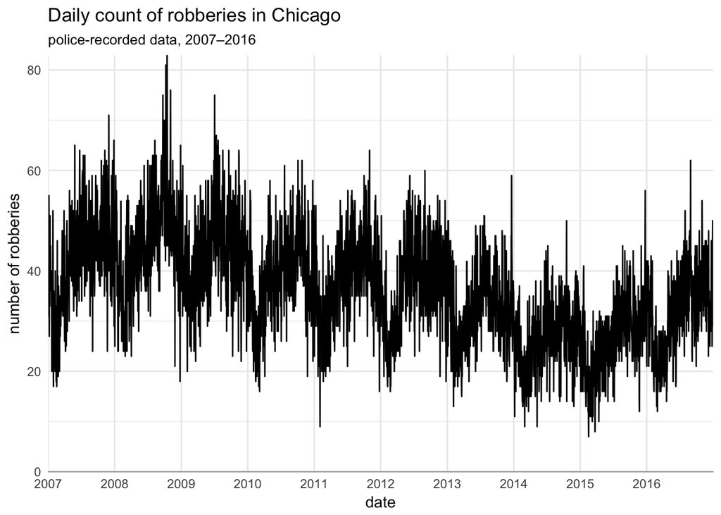

```r
ggplot(data = chi_rob_counts,
       mapping = aes(date, crime_count)) +
  geom_line() +
  scale_x_date(date_breaks = "1 year", date_labels = "%Y", expand = c(0, 0)) +
  scale_y_continuous(limits = c(0, NA), expand = c(0, 0)) +
  theme_minimal() +
  theme(
    panel.grid.minor.x = element_blank(),
    axis.line.x = element_line(colour = "grey60")
  ) +
  labs(title = "Daily count of robberies in Chicago",
       subtitle = "police-recorded data, 2007–2016",
       x = "date",
       y = "number of robberies")
```

As an aside, some notes about this chart:

- `scale_x_date()` specifies some changes to the defult x (horizontal) axis. Specifically:
  - `date_breaks = "1 year"` gives one-year intervals between the labels,
  - `date_labels = "%Y"` produces labels that show only the year ([list of formatting codes](https://www.rdocumentation.org/packages/base/versions/3.4.3/topics/strptime)), and
  - `expand(0, 0)` removes the default space at either end of the axis.
- `scale_y_continuous()` specifies changes to the default y (vertical) axis. Specifically `limits = c(0, NA)` specifies that the y axis of the chart will begin at zero and end at the highest value in the data. Starting the axis at zero is useful because it means people can judge the proportional change in number of crimes over time.
- `theme_minimal()` changes the appearance of the chart to emphasise the data and de-emphasise other elements such as the axes. Other [ggplot themes](http://ggplot2.tidyverse.org/reference/lims.html) are available.
- `theme()` makes changes to the default settings for the chart appearance. Specifically:
  - `panel.grid.minor.x = element_blank()` removes the minor verticle grid lines that would otherwise appear halfway through each year.
  - `axis.line.x = element_line(colour = "grey60")` adds a grey line along the x axis to slightly emphasise the difference between zero crimes (represented by the line) and the data.

## Plotting counts of crime per week

The code below is identical to code for producing daily counts, except for the line

```
`date = as_date(floor_date(datetime, unit = "week", week_start = 1))`
```

This code uses `floor_date()` from the `lubridate` package to create a new column in the data called `date`[^1] for the week in which the crime occurred. The week is represented as the date of the first day of the relevant week, because `ggplot()` expects the data to be in the form of dates. `week_start = 1` specifies that the week starts on a Monday, but you can change this to another day if you prefer.

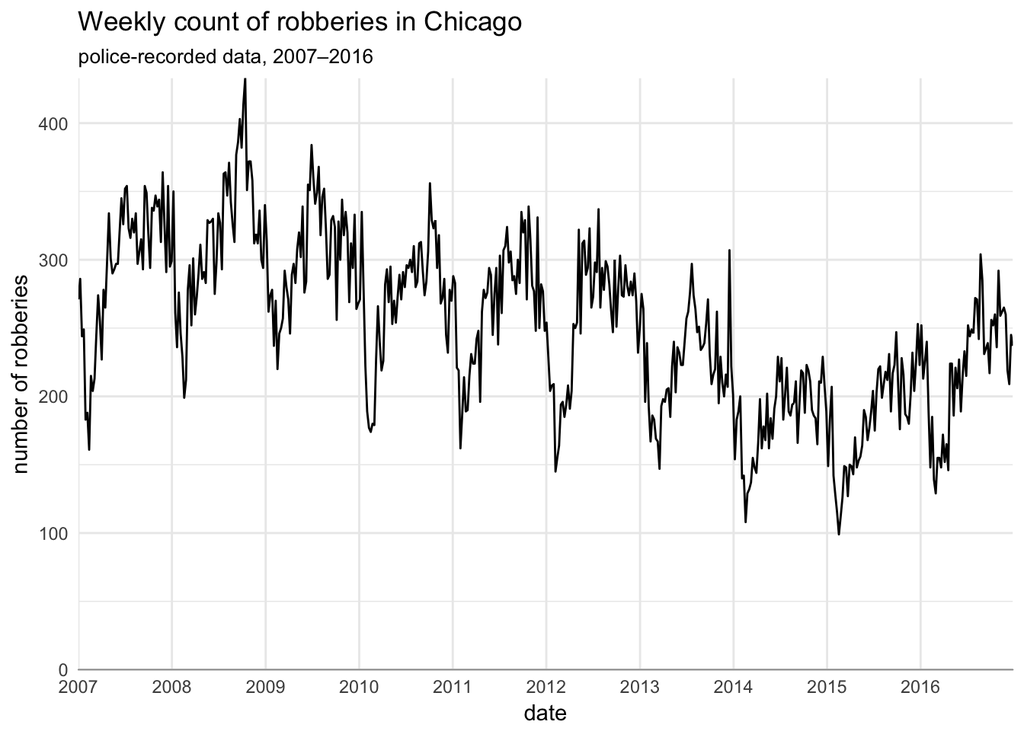

```r
chi_rob %>%
  mutate(
    date = as_date(floor_date(datetime, unit = "week", week_start = 1))
  ) %>%
  group_by(date) %>%
  summarise(crime_count = n()) %>%
  arrange(date) %>%
  ggplot(mapping = aes(date, crime_count)) +
    geom_line() +
    scale_x_date(date_breaks = "1 year", date_labels = "%Y", expand = c(0, 0)) +
    scale_y_continuous(limits = c(0, NA), expand = c(0, 0)) +
    theme_minimal() +
    theme(
      panel.grid.minor.x = element_blank(),
      axis.line.x = element_line(colour = "grey60")
    ) +
    labs(title = "Weekly count of robberies in Chicago",
         subtitle = "police-recorded data, 2007–2016",
         x = "date",
         y = "number of robberies")
```

## Plotting counts of crime each month

You can produce a chart of the count of crimes each month using the same code as for a weekly chart by simply changing `unit = "week"` to `unit = "month"` in the `floor_date()` function. *However*, you are strongly recommended not to do this because plots of monthly counts can be misleading. This is for two reasons:

1. Months are not the same length: January is 11% longer than February is (in non-leap years).
2. The frequency of crime varies substantially through each week (e.g. there are typically more assaults on Fridays than Tuesdays), but months don’t have the same number of (for example) Fridays in them.

You can see this by looking at plots of monthly robbery counts based on data that have no monthly or other seasonal patterns in them. Specifically, lets assume that every day has the same number of robberies, except that there are 25% more robberies on Fridays and Saturdays, and 25% fewer on Sundays.

```r
chi_rob_basic <- tibble(
  date = range(chi_rob$datetime) %>% as_date() %>% { seq.Date(.[1], .[2], by = "day") },
  day = wday(date, label = TRUE),
  crime_count = mean(chi_rob_counts$crime_count)
) %>%
  mutate(crime_count = round(case_when(
    day %in% c("Fri", "Sat") ~ crime_count * 1.25,
    day %in% c("Sun") ~ crime_count * 0.75,
    TRUE ~ crime_count
  )))
```

We know there are no monthly patterns in these data, so we might expect there to be no variations in the count of crimes each month. But if we plot the data (focusing on just the data for 2007), we see this is not the case.

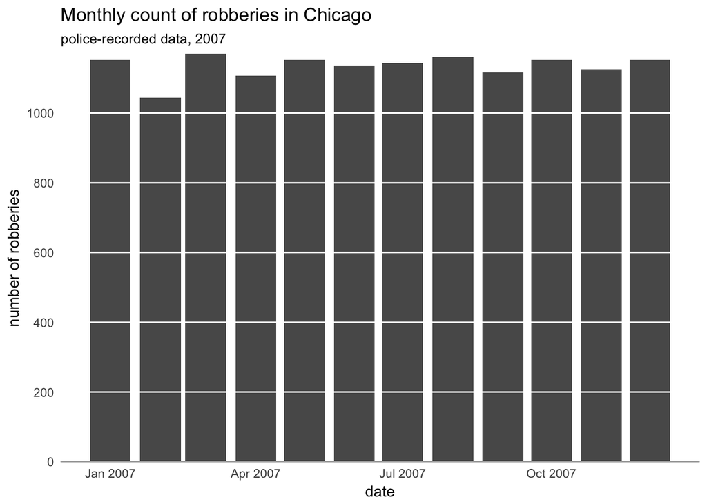

```r
chi_rob_basic %>%
  mutate(
    date = as_date(floor_date(date, unit = "month", week_start = 1))
  ) %>%
  group_by(date) %>%
  summarise(crime_count = sum(crime_count)) %>%
  arrange(date) %>%
  filter(year(date) == 2007) %>%
  ggplot(mapping = aes(date, crime_count)) +
    geom_bar(stat = "identity", colour = NA) +
    scale_y_continuous(limits = c(0, NA), breaks = seq(0, 1000, 200), expand = c(0, 0)) +
    geom_hline(yintercept = seq(0, 1000, 200), col = "white", lwd = 0.5) +
    theme_minimal() +
    theme(
      panel.grid.major = element_blank(),
      panel.grid.minor = element_blank(),
      axis.line.x = element_line(colour = "grey60")
    ) +
    labs(title = "Monthly count of robberies in Chicago",
         subtitle = "police-recorded data, 2007",
         x = "date",
         y = "number of robberies")
```

Instead of 12 equal-height bars, we can see substantial variation in crime counts throughout the year *not because there are any changes in crime, but solely because months are a bad unit of analysis*.

Months can be particularly problematic in short-term analysis, for example when data from one month are compared to the previous month in a monthly performance meeting. For example, there is an apparent 12% increase in crime between February and March, caused solely by March being a longer month and having five Fridays and Saturdays compared to four in February.

# Understanding changes in crime over time

It is common for there to be multiple complicated patterns in crime data. For example, in the chart of daily robbery counts above, we can see that there are rhythmic changes in the data, which we might expect to follow the seasons. We can also see what looks like a decrease in the number of robberies from 2009 until 2015, followed by an apparent increase.

Reliably identifying these patterns is difficult because the data are noisy: there are big variations in crime counts from one day to the next. One way to deal with this is to ‘decompose’ the data into different parts.

Time series data can be thought of as being the result of three different processes combining to produce the daily count of crimes. These processes are:

- a long-term trend (e.g. crime going up over time),
- seasonal variation that changes in repeating cycles (e.g. more crimes in the summer, fewer in winter), and
- ‘remainder’ variation from day to day as the result of short-term influences (e.g. more crimes on a sunny public holiday).

We can `stl()` function (from the loaded-by-default `stats` package) to estimate the underlying trend, seasonal and remainder variation from the daily counts of crime. This is useful because it allows us to look at each component separately, even though we only have the combined counts.

The `stl()` function expects data to be in the format of a ‘univariate time series’, so first we must convert the data before decomposing it. More specifically:

- `arrange(date)` makes sure the data are arranged in ascending order of date. This is important because `ts()` assumes the data are sorted.
- `ts()` converts the data into a time series object. This function was not designed to be used inside pipelines, so we use braces to isolate this function from the pipeline. This means we must specify the arguments of `ts()` manually, using `.` as a placeholder for `chi_rob_counts`. We specify:
  - Values of the series (i.e. the robbery counts).
  - The first date in the series. This is expressed in the unusual format `c(year, day-of-year)`, so we use `min(.$date)` to find the earliest date in the series then `year()` and `yday()` to get the year and the day of the year for that date[^2].
  - The ‘frequency’ of the series, which is the number of observations (in this case, days) we expect within each seasonal cycle in the data. At the moment we want to look at annual cycles, so we specify 365 observations (i.e. days) in each cycle[^3].
- `stl()` estimates the different components of the time series. Note that this is an estimate, so it may not always be perfect.
- `plot()` plots the decompose time-series data using the default settings for the results of the `stl()` function.

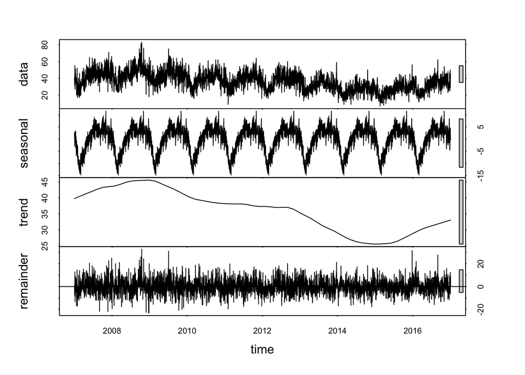

```r
chi_rob_counts %>%
  arrange(date) %>%
  { ts(.$crime_count,
       start = c(year(min(.$date)), yday(min(.$date))),
       frequency = 365)
  } %>%
  stl(s.window = 365) %>%
  plot()
```

All these things are easier to see when we separate them out, compared to the original daily-count plot.

# Aoristic analysis

Analysing temporal patterns of violent crimes such as robberies is relatively easy because the victim can (in most cases) tell police approximately when the crime occurred. This is not the case for many property crimes such as burglary or vehicle theft, for which the victim will often only be able to say when they left the property unattended and when they returned to find the property had been stolen. These offences as sometimes referred to as ‘aoristic’ crime, combining the Greek terms for ‘without’ and ‘time’.

Aoristic analysis is designed to estimate the temporal patterns of aoristic crimes. It does this by calculating the probability of each crime occurring in each time period during which it could have occurred. For example, if a crime could have occurred anywhere between 08:10 and 17:55 hours, aoristic analysis assumes that 1/10th of a crime occurred in each of the ten hours between 08:00 and 18:00 hours during which the crime could have occurred. By aggregating these fractions of crimes from all the offences occurring during a particular period, it is possible to estimate when the most crimes occurred.

We will use the data on thefts of and from motor vehicles in New York City to show how to carry out aoristic analysis in R. The following code produces a chart showing the estimated number of crimes occurring during each hour of the day.

- The `aoristic()` package cannot handle the data in its current format (called a ‘tibble’), so `as.data.frame()` converts the data into a format that the aoristic functions can process.
- `aoristic.df()` converts the data into a format ready for aoristic processing.
- `aoristic.all.graph()` estimates the number of crimes occurring during each hour.
- `ggplot()` shows this information as a chart. Specifically:
  - `geom_bar(stat = "identity")` specifies that the values in the data column `freq` are counts of crimes in each hour (i.e. the height of each bar),
  - `geom_hline()` produces horizontal lines to break-up the bars, as [recommended by Edward Tufte](https://maidens.github.io/jekyll/update/2016/11/23/Tufte-Bar-Chart-Julia.html).

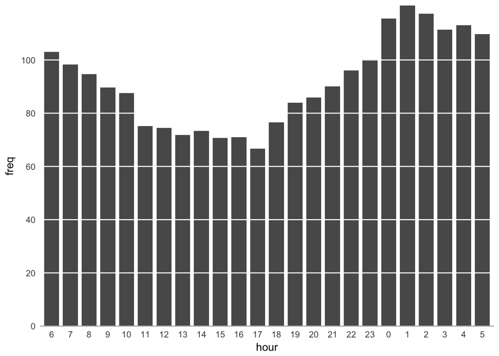

```r
nyc_tmv %>%
  as.data.frame() %>%
  aoristic.df("date_start", "date_end") %>%
  aoristic.all.graph() %>%
  ggplot(mapping = aes(x = hour, y = freq)) +
    geom_bar(stat = "identity", width = 0.8) +
    scale_y_continuous(breaks = seq(0, 100, 20), expand = c(0, 0)) +
    geom_hline(yintercept = seq(0, 100, 20), col = "white", lwd = 0.5) +
    theme_minimal() +
    theme(
      panel.grid.major = element_blank(),
      panel.grid.minor = element_blank(),
      axis.line.x = element_line(colour = "grey60")
    )
```

From this, we can see that vehicle crimes peak overnight, with the highest number of crimes between midnight and 07:00.

[^1]: This column is called date, as in the previous example, so that we can keep the rest of the code the same.
[^2]: We need the day of the year because the frequency is specified in days. If the frequency was specified in months, we would need to month of the year as the second element of the vector passed to `start`.
[^3]: Unfortunately the `stl()` function cannot handle leap years, so we ignore them and assume every year has 365 days.